# Stats 769 Lab 9

Chase Robertson

2022-10-12

```r
library(e1071)
library(MASS)
```

# Introduction

1. In your own words, describe briefly the data and the data mining problems that are studied in this lab.
- In this lab, 16x16 grayscale images of handwritten digits are used to classify into their appropriate number. Classification of this dataset is known to be difficult, with a 2.5% error rate being considered excellent performance. SVM classification is applied to observations labeled as digits 2 and 3.
- SVM regression is also applied to the 1970’s Boston housing value dataset.

```r
set.seed(1234)

train = read.csv("ziptrain.csv")
train = subset(train, digit==2 | digit==3)
train$digit = factor(train$digit)

test = read.csv("ziptest.csv")
test = subset(test, digit==2 | digit==3)
test$digit = factor(test$digit)

table(c(train$digit, test$digit))
```

```
##
##   2   3
## 929 824
```

# Using Two Predictors

2. In Tasks 2-4, let us consider only two predictors, p167 and p105. (Note: p167 is the most important predictor found in Task 5, Lab 8, and p105 is the least correlated with p167 among the top ten more important predictors.)

```r
predictors <- subset(train, select=c(digit, p167, p105))
str(predictors)
```

```
## 'data.frame':    1389 obs. of  3 variables:
##  $ digit: Factor w/ 2 levels "2","3": 2 2 2 2 2 1 2 2 1 1 ...
##  $ p167 : num  -1 -1 -1 -1 -1 1 -1 -1 -0.731 -1 ...
##  $ p105 : num  1 0.936 0.651 1 0.609 -0.632 1 0.128 -1 -0.991 ...
```

Consider fitting support vector machines using the linear kernel, for cost=0.0001, 0.001, 0.01, 0.1, respectively.

```r
attach(predictors)
```

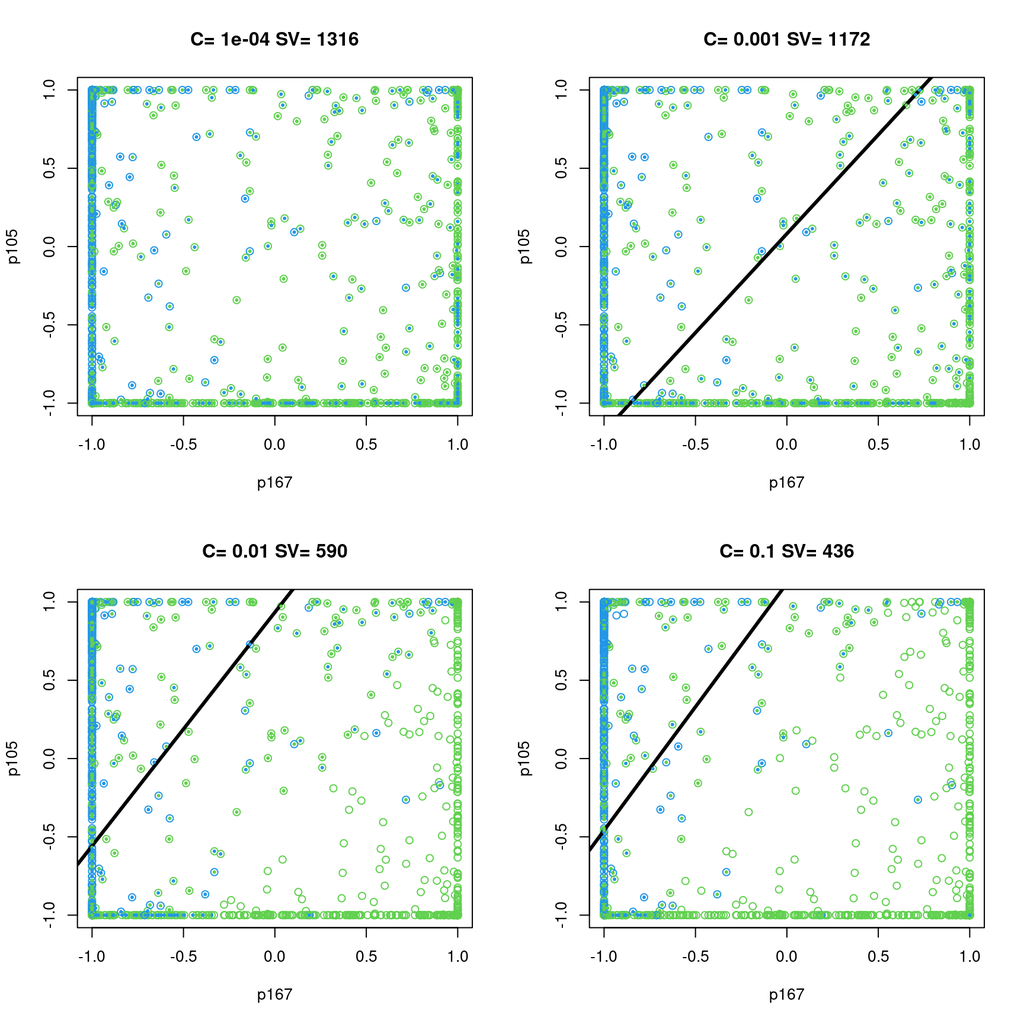

```r
costs <- 10^(-4:-1)
form <- digit ~ p105 + p167
r <- lapply(costs, function(x) svm(form, data=predictors, kernel='linear', scale=F, cost=x))

col <- as.numeric(digit)+2
par(mfrow=c(2,2))
for (i in seq_along(r)) {
    plot(p167, p105, col=col, main=paste('C=', costs[i], 'SV=', summary(r[[i]])$tot.nSV))
    beta = coef(r[[i]])
    abline(-beta[-2] / beta[2], lwd=3)
    s = r[[i]]$index
    points(p167[s], p105[s], pch=20, cex=0.5, col=col)
}
```

What is the effect of cost here, in terms of the decision boundary and the number of support vectors?

- Increasing the cost parameter effectively decreases the number of support vectors, leading to a more tight fit to the data. With C=0.0001, the number of support vectors is so high and the fit is so relaxed that the decision boundary isn’t even within the range of known values.
3. Compute the training and test errors (misclassification rates) for each of the support vector machines found in Task 2.

```r
err <- function(model, gamma=F, subset=T) {
    out <- list(cost=model$cost)
    if (gamma) out$gamma <- model$gamma
    if (subset) out$train_err <- mean(predict(model, predictors) != predictors$digit)
    else out$train_err <- mean(predict(model, train) != train$digit)
    out$test_err <- mean(predict(model, test) != test$digit)
    out
}
```

```r
(errs <- t(sapply(r, err)))
```

```
##      cost  train_err test_err
## [1,] 1e-04 0.4737221 0.456044
## [2,] 0.001 0.1612671 0.1758242
## [3,] 0.01  0.1202304 0.1373626
## [4,] 0.1   0.1238301 0.1346154
```

Should the training and test errors be similar to each other in these cases? Explain why or why not.

- Training and test errors should indeed be very similar for each of these linear models. Linear models are not flexible enough to make lower training error due to overfitting very likely.

Find the best value for cost, based on the test errors.

```r
(best_cost <- errs[[which.min(errs[,3]),1]])
```

```
## [1] 0.1
```

4. Consider using radial kernels for support vector machines, with the cost-value fixed at the optimal one found in Task 3.

Consider fitting support vector machines, for gamma=0.0001, 0.1, 10, 1000, respectively.

```r
gamma <- 10^c(-4, -1, 1, 3)
r <- lapply(gamma, function(x) svm(form, data=predictors, kernel='radial', scale=F,
                                   cost=best_cost, gamma=x, probability=T))
```

```r
x = seq(min(p167), max(p167), len=length(p167))
y = seq(min(p105), max(p105), len=length(p167))
g <- expand.grid(x, y)
data <- data.frame(p167=g[,1], p105=g[,2])

preds <- lapply(r, function(x) predict(x, data, probability=T))
```

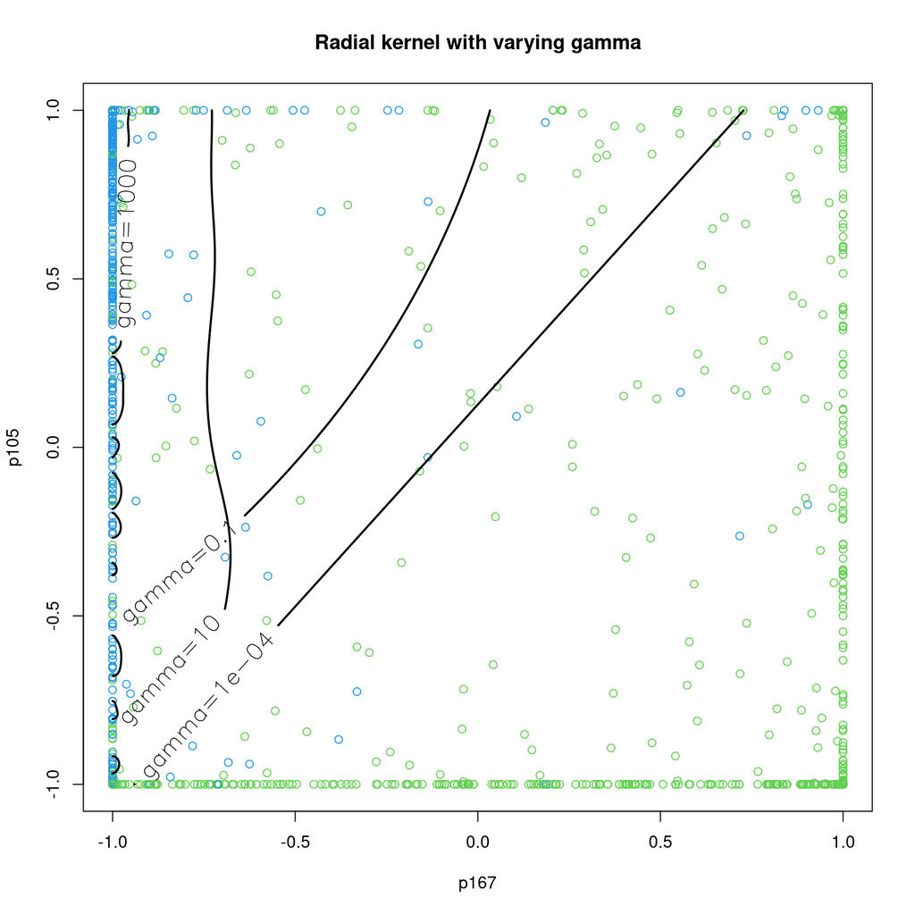

```r
plot(p167, p105, col=col, main="Radial kernel with varying gamma")
for (i in seq_along(gamma)) {
    fit <- r[[i]]
    probs <- attr(preds[[i]], "probabilities")[,1]
    z <- matrix(probs, nrow=length(p167))
    contour(x, y, z, levels=0.5, lwd=2, labels=paste0('gamma=', fit$gamma),
            drawlabels=T, method="flattest", labcex=1.5, add=TRUE)
}
```

What is the effect of gamma here, in terms of the decision boundary and the number of support vectors?

- An increase of gamma leads to a more flexible nonlinear boundary, with very small gamma fitting a straight line, and very high gamma fitting a wiggling line which sticks to the noisy training data very tightly.

Compute the training and test errors for each of the support vector machines built. What is the optimal value for gamma here?

```r
(errs <- t(sapply(r, err, gamma=T)))
```

```
##      cost gamma train_err test_err
## [1,] 0.1  1e-04 0.4737221 0.456044
## [2,] 0.1  0.1   0.1223902 0.1346154
## [3,] 0.1  10    0.1007919 0.1071429
## [4,] 0.1  1000  0.1706263 0.2087912
```

```r
detach(predictors)
```

- The optimal value for gamma seems to be 10 here, as it results in least test error.

Do you think using radial kernels helps here, as compared with the linear kernel?

- Using a radial kernel does seem to help here, as compared to the linear kernel. It is crucial to tune the hyperparameters properly, though, as the other attempted gamma values did not lead to superior performance over the linear kernel models.

# Using All Predictors

5. Now consider using all 256 predictors in support vector machines, using radial kernels.

Fit the support vector machine, using the optimal values for cost and gamma found in Tasks 3 and 4.

Compute both the training and test errors for this model.

```r
r <- svm(digit ~ ., data=train, kernel='radial', scale=F, cost=0.1, gamma=10)

t(err(r, gamma=T, subset=F))
```

```
##      cost gamma train_err test_err
## [1,] 0.1  10    0.4737221 0.456044
```

6. With all 256 predictors used, find the best values for cost and gamma based on 10-fold cross-validation (just one run) from the train set.

```r
set.seed(1234)
(rt <- tune(svm, digit ~ ., data=train, kernel='radial', scale=F,
           ranges=list(cost=10^(-3:3), gamma=10^(-3:3))))
```

```
##
## Parameter tuning of 'svm':
##
## - sampling method: 10-fold cross validation
##
## - best parameters:
##  cost gamma
##     1  0.01
##
## - best performance: 0.008638307
```

Compute both the training and test errors of the best model found.

```r
t(err(rt$best.model, gamma=T, subset=F))
```

```
##      cost gamma train_err test_err
## [1,] 1    0.01  0         0.02472527
```

# Support Vector Regression

7. Consider using only one predictor lstat (without scaling) for the response medv, in the Boston data set.

Choose manually a set of values for eps, cost and gamma so that the support vector regression fit (with radial kernels) visually looks okay.

```r
attach(Boston)
```

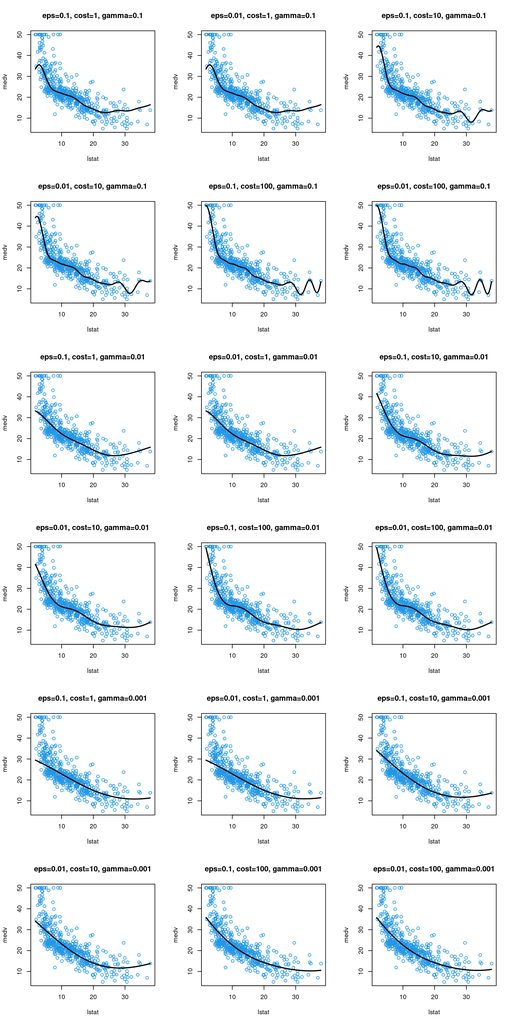

```r
params <- expand.grid(eps=c(0.1, 0.01), cost=c(1, 10, 100), gamma=c(0.1, 0.01, 0.001))
x <- seq(min(lstat), max(lstat), 0.1)

par(mfrow=c(6,3))
for (i in seq(nrow(params))) {
    br <- svm(medv ~ lstat, data=Boston, kernel='radial', scale=F,
          eps=params[i,1], cost=params[i,2], gamma=params[i,3])
    plot(lstat, medv, col=col[1], main=paste(names(params), params[i,], sep='=', collapse=", "))
    lines(x, predict(br, data.frame(lstat=x)), lwd=2)
}
```

- Epsilon=0.1, Cost=100, gamma=0.1 looks to be a good fit. Perhaps a bit overfit, but captures the steep relationship at very low values of lstat.
8. Consider using all predictors (without scaling) for the response medv.

Fix a reasonably value for eps (or you may also include it in the following cross-validation search for best values).

Find the best values for cost and gamma, using 10-fold cross-validation (just one run).

```r
(br_t <- tune(svm, medv ~ ., data=Boston, kernel='radial', scale=F,
            eps=0.1, ranges=list(cost=10^(-4:3), gamma=10^(-4:3))))
```

```
##
## Parameter tuning of 'svm':
##
## - sampling method: 10-fold cross validation
##
## - best parameters:
##  cost gamma
##  1000 1e-04
##
## - best performance: 18.89346
```

Provide a rough estimate of the proportion of variation reduction by the best model found.

```r
1 - min(br_t$performance[,'error']) / var(medv)
```

```
## [1] 0.7766379
```

9. Re-do Task 8, with all predictors standardised.

```r
(br_s <- tune(svm, medv ~ ., data=Boston, kernel='radial', scale=TRUE,
            eps=0.1, ranges=list(cost=10^(-4:3), gamma=10^(-4:3))))
```

```
##
## Parameter tuning of 'svm':
##
## - sampling method: 10-fold cross validation
##
## - best parameters:
##  cost gamma
##    10   0.1
##
## - best performance: 10.34077
```

```r
detach(Boston)
```

Does the scaling help here?

- Scaling does help here, as it effectively equalises the influence of each variable on the error calculations. Without scaling, those variables with wider ranges would necessarily have more impact on the fitted regression. With scaling, the best set of hyperparameters changes along with an improvement in performance.

# Summary

10. Write a summary of the entire report.
- In this report, Support Vector Machines are applied to both a classification and regression task. Linear and radial kernels are attempted, with different hyperparameter combinations and analysis of their impact. The power and necessity of data scaling and proper hyperparameter tuning in this context is emphasised, with wide performance differences between models.